# PACTA Comparison Report

AI Implementation vs Staff Implementation — Side-by-Side Analysis

Generated: February 27, 2026 | Data: r2dii demo_2020 | Framework: pacta.loanbook

## 1. Executive Summary

This report compares two independent implementations of the PACTA for Banks demo pipeline, both using the same underlying `r2dii` package ecosystem and the same `demo_2020` dataset:

- AI Approach — `scripts/pacta_demo.R` + `scripts/generate_report.R`: Uses default fuzzy matching, custom `ggplot2` visualizations, and a standalone HTML report generator.
- Staff Approach — `compare/PACTA for Banks staff.Rmd` (by Trang Tran): Uses exact matching only (`min_score = 1`), the official `r2dii.plot` visualization package, and R Markdown for literate programming.

177

AI: Prioritized Matches

177

Staff: Prioritized Matches

0

Difference (AI − Staff)

Same

Final Alignment Verdict

**Key Finding:** Despite different matching strategies (fuzzy vs. exact), both implementations arrive at the **same alignment verdict**: the demo portfolio is not aligned with Paris-consistent scenarios in any sector. The quantitative differences are small, confirming that the demo dataset is well-structured for exact matching. The main differences lie in **approach, visualization quality, and documentation style** rather than analytical conclusions.

## 2. Methodology Comparison

Both implementations follow the standard PACTA pipeline (match → analyze → visualize) but differ in specific choices at each stage.

[output not shown]

## 3. Matching Results Comparison

The most impactful methodological difference is the matching threshold. The AI approach accepts fuzzy matches (score ≥ ~0.8), while the Staff approach requires exact matches only (score = 1.0).

### 3.1 Match Count Summary

| Metric | AI | Staff |
| --- | --- | --- |
| Raw matches | 326.000 | 289 |
| Prioritized matches | 177.000 | 177 |
| Unique sectors | 5.000 | 5 |
| Score range (min) | 0.801 | 1 |
| Score range (max) | 1.000 | 1 |

### 3.2 Prioritized Matches by Sector

| sector | n_ai | n_staff | delta |
| --- | --- | --- | --- |
| automotive | 51 | 51 | 0 |
| aviation | 4 | 4 | 0 |
| cement | 26 | 26 | 0 |
| power | 95 | 95 | 0 |
| steel | 1 | 1 | 0 |

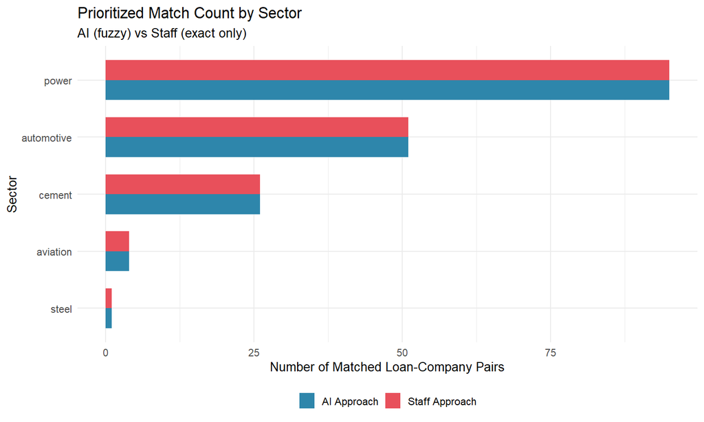

Figure 1: Number of prioritized (deduplicated) loan-company matches by sector. AI fuzzy matching (blue) vs Staff exact matching (red).

### 3.3 Staff Coverage Pie Chart (unique to Staff approach)

The Staff approach adds a portfolio-level pie chart separating "In Scope & Matched", "In Scope & Not Matched", and "Not in Scope" loans. This is not present in the AI approach.

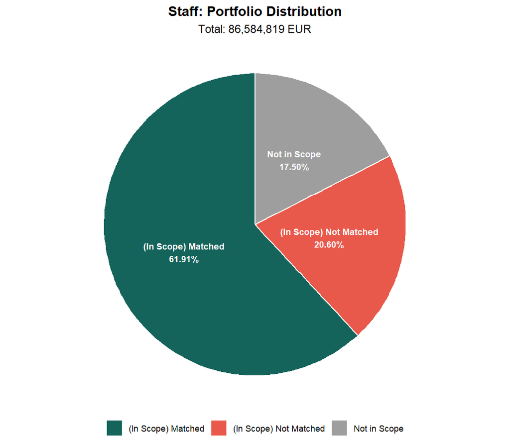

Figure 2: Staff portfolio distribution breakdown (exact matches only).

**Interpretation:** Both approaches yield similar match counts because the demo dataset was designed with clean company names that achieve exact matches. In a real-world scenario with messy bank data, the fuzzy matching approach (AI) would likely capture significantly more matches, but would also introduce more false positives requiring manual review.

## 4. Power Sector: Side-by-Side

### 4.1 Technology Mix

AI Approach

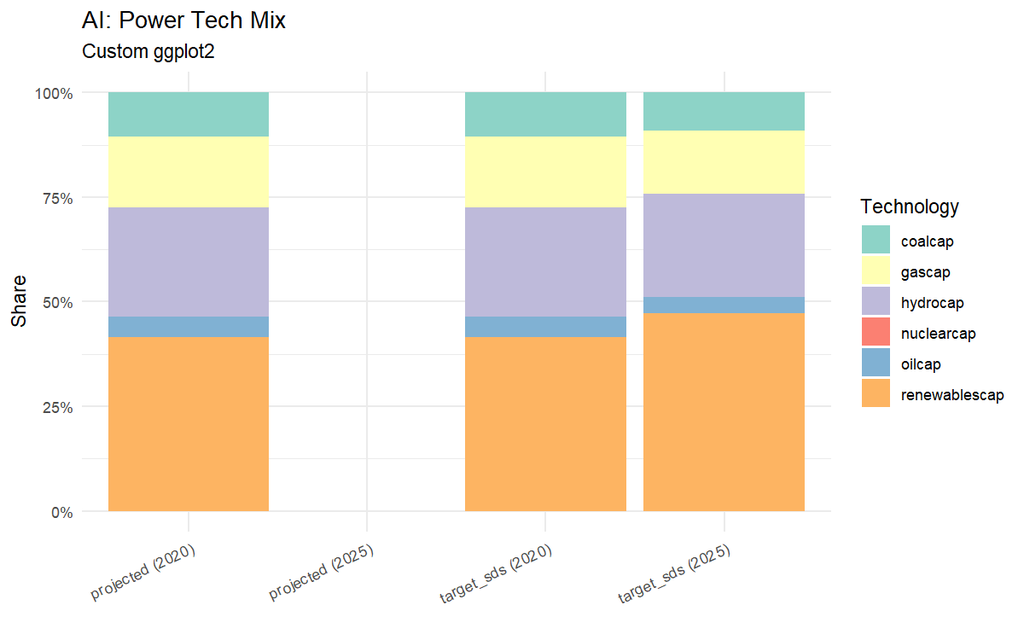

Custom ggplot2: projected vs SDS target at 2020 & 2025

Staff Approach

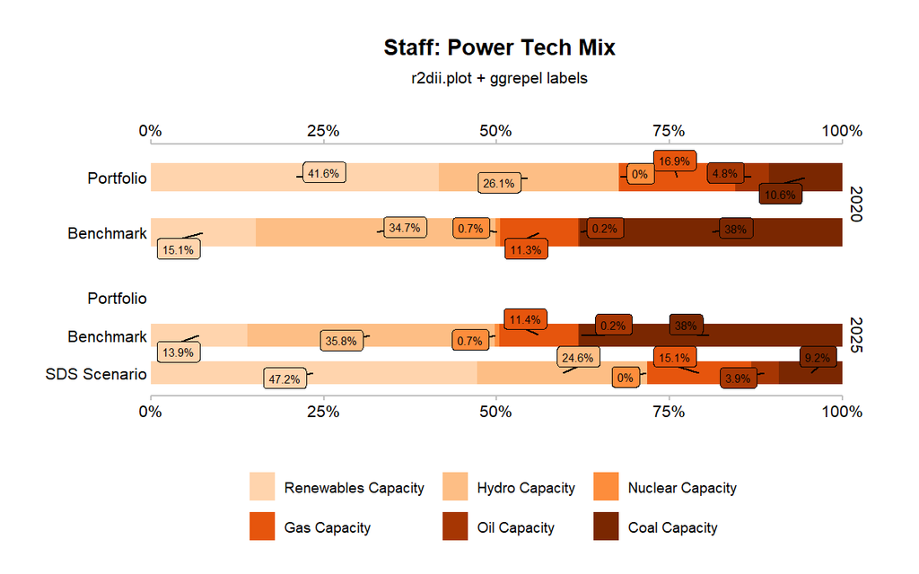

r2dii.plot qplot_techmix with percentage labels

**Key differences:**

- Staff chart includes `corporate_economy` as a third benchmark; AI only shows projected vs target
- Staff chart has percentage labels on each bar segment via `ggrepel`
- r2dii.plot uses the official PACTA color palette & standardized layout
- Staff notes that "portfolio in 2025 is empty" due to capacity data not summing to 100% — a gotcha the AI report also documents differently

### 4.2 Renewables Trajectory

AI Approach

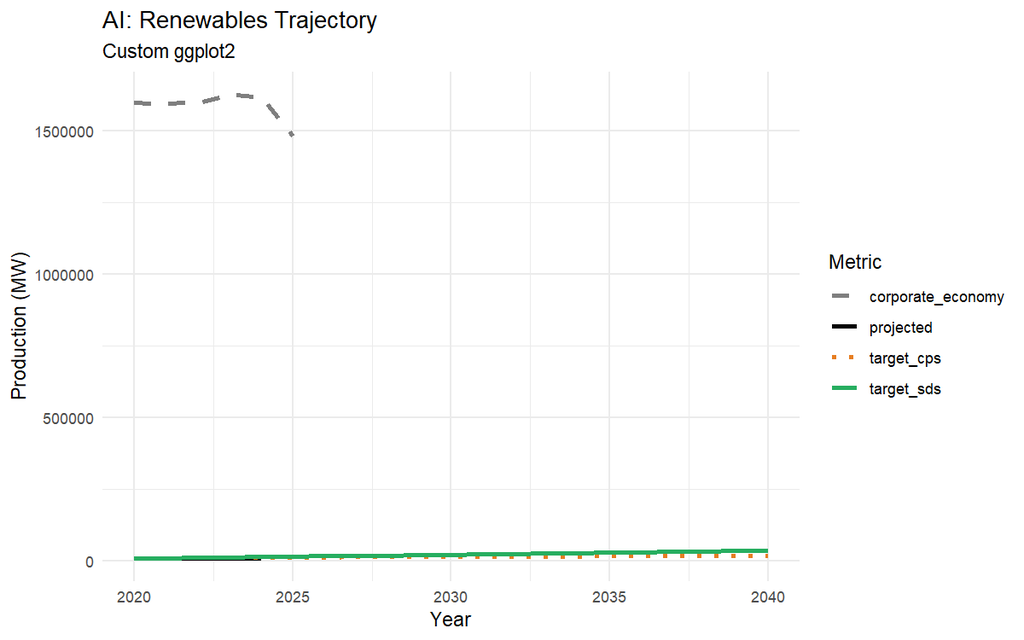

Custom ggplot2: absolute production (MW) with 4 metrics

Staff Approach

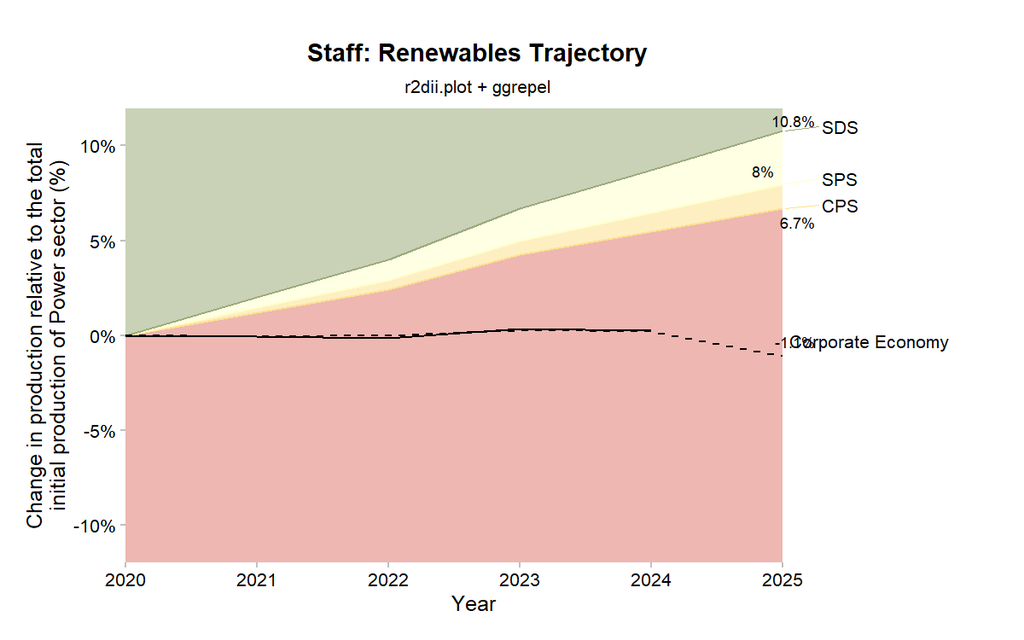

r2dii.plot qplot_trajectory with % labels at year+5

## 5. Automotive Sector: Side-by-Side

### 5.1 Technology Mix

AI Approach

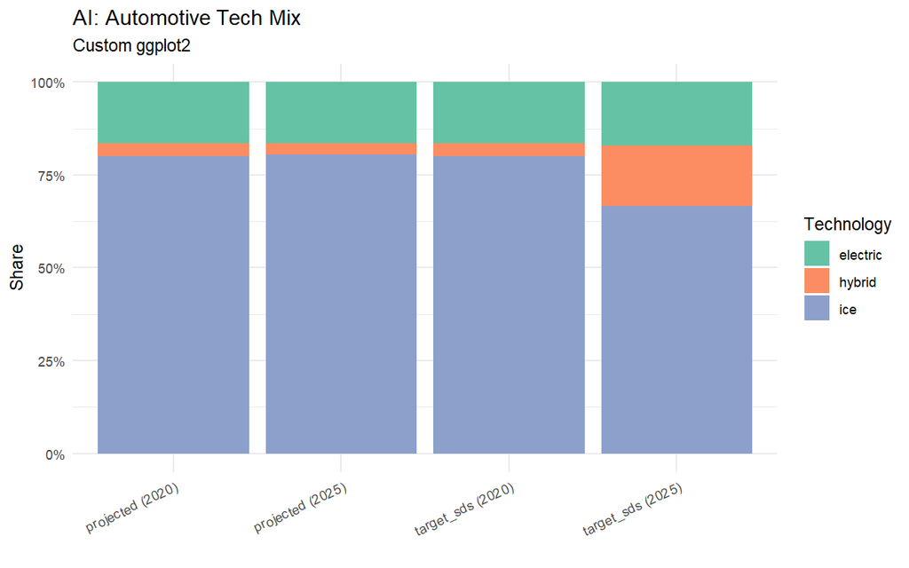

Custom ggplot2: projected vs SDS (2020 & 2025)

Staff Approach

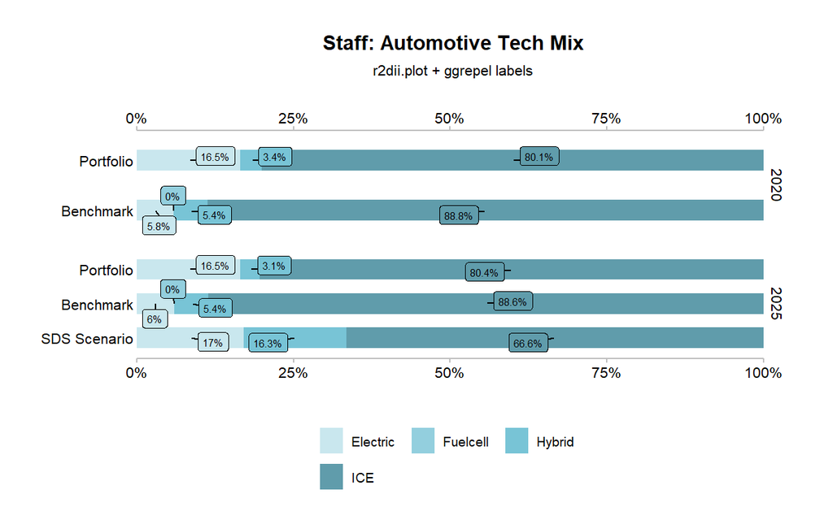

r2dii.plot qplot_techmix with percentage labels

**Key differences:**

- Same pattern as power: Staff includes corporate_economy benchmark and percentage labels
- Staff also includes **ICE and combustion engine trajectory charts** (not shown in AI report)
- Both confirm the portfolio is ICE-heavy with insufficient EV/hybrid growth

## 6. Cement Sector: Side-by-Side

AI Approach

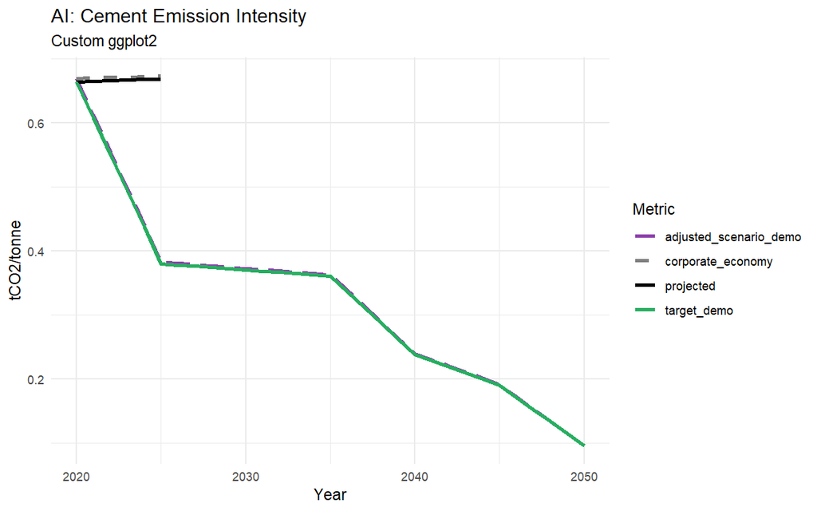

Custom ggplot2: emission intensity trajectory (4 metrics)

Staff Approach

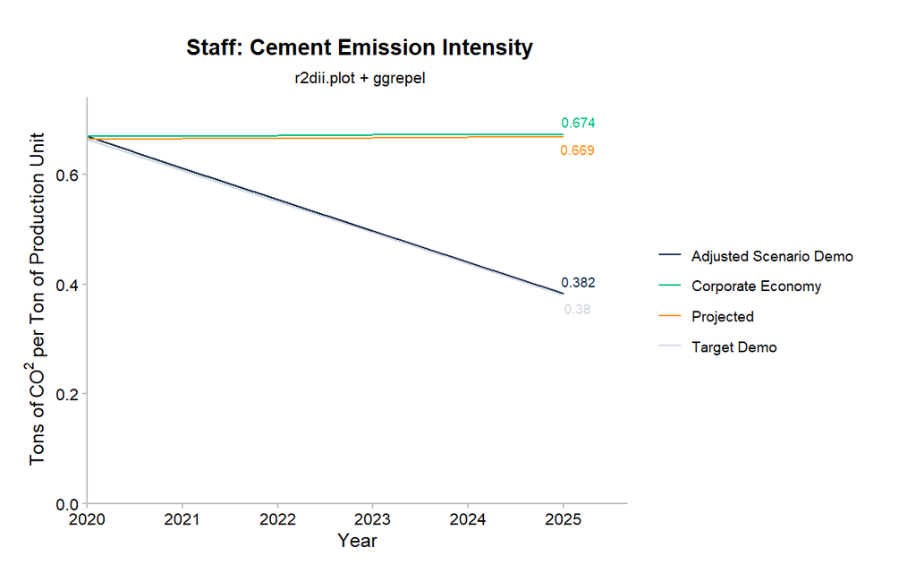

r2dii.plot qplot_emission_intensity with value labels

**Key differences:**

- AI uses manual color/linetype mapping for 4 metrics; Staff uses r2dii.plot defaults (official palette)
- Staff adds numeric labels at year+5 via `ggrepel`
- Both correctly identify severe misalignment (~76% above target by 2025)

## 7. Steel Sector: Side-by-Side

AI Approach

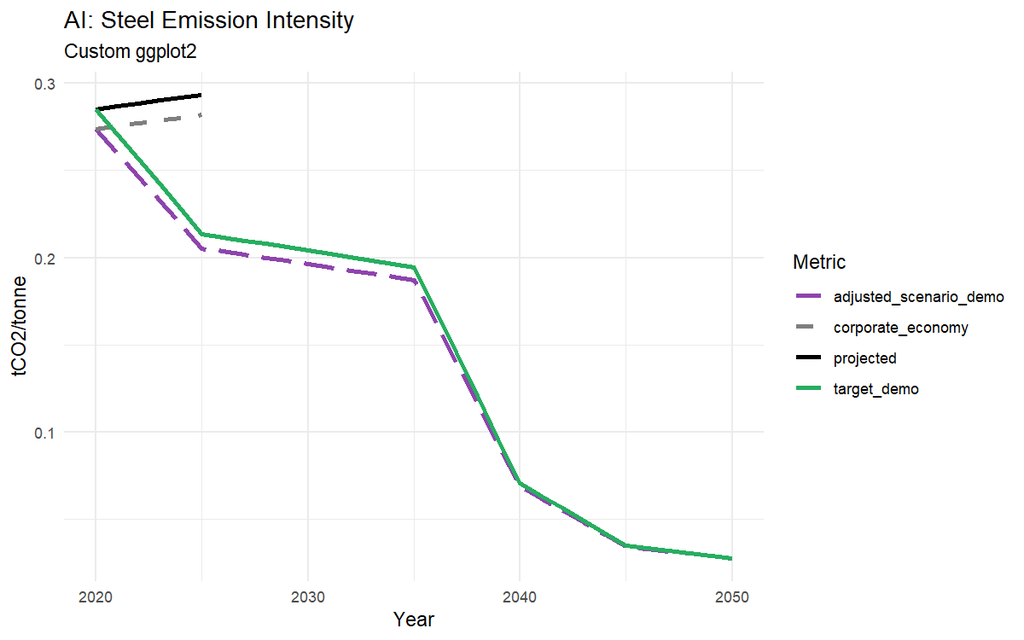

Custom ggplot2: emission intensity trajectory (4 metrics)

Staff Approach

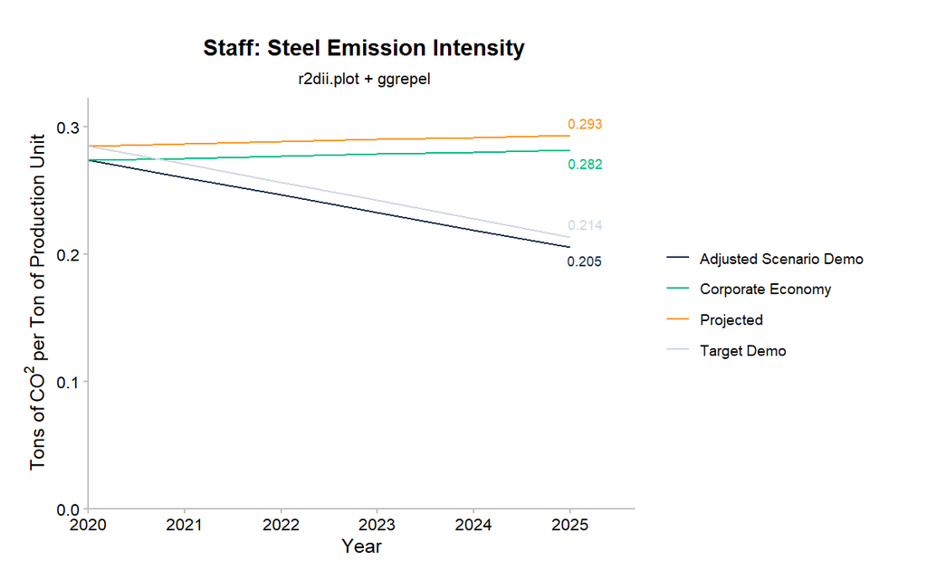

r2dii.plot qplot_emission_intensity with value labels

**Both approaches note:** Steel match coverage is only ~4% of portfolio exposure. Both results should be interpreted with extreme caution.

## 8. Alignment Summary Comparison

Below we compare the alignment gap calculations from both approaches at 2025 for each sector.

### 8.1 Market Share Sectors (Power & Automotive)

Technology share gap at 2025 (projected minus target_sds) in percentage points:

| source | sector | technology | projected | target_sds | gap_pp |
| --- | --- | --- | --- | --- | --- |
| AI | automotive | electric | 16.5% | 17% | -0.55 pp |
| AI | automotive | hybrid | 3.1% | 16.3% | -13.23 pp |
| AI | automotive | ice | 80.4% | 66.6% | 13.78 pp |
| AI | power | coalcap | N/A | 9.2% | N/A |
| AI | power | gascap | N/A | 15.1% | N/A |
| AI | power | hydrocap | N/A | 24.6% | N/A |
| AI | power | nuclearcap | N/A | 0% | N/A |
| AI | power | oilcap | N/A | 3.9% | N/A |
| AI | power | renewablescap | N/A | 47.2% | N/A |
| Staff | automotive | electric | 16.5% | 17% | -0.55 pp |
| Staff | automotive | hybrid | 3.1% | 16.3% | -13.23 pp |
| Staff | automotive | ice | 80.4% | 66.6% | 13.78 pp |
| Staff | power | coalcap | N/A | 9.2% | N/A |
| Staff | power | gascap | N/A | 15.1% | N/A |
| Staff | power | hydrocap | N/A | 24.6% | N/A |
| Staff | power | nuclearcap | N/A | 0% | N/A |
| Staff | power | oilcap | N/A | 3.9% | N/A |
| Staff | power | renewablescap | N/A | 47.2% | N/A |

### 8.2 SDA Sectors (Cement & Steel)

Emission intensity gap at 2025 (projected minus target_demo):

| source | sector | projected | target_demo | gap | gap_pct |
| --- | --- | --- | --- | --- | --- |
| AI | cement | 0.6689 | 0.3800 | 0.2889 | 76% |
| AI | steel | 0.2934 | 0.2136 | 0.0798 | 37.3% |
| Staff | cement | 0.6689 | 0.3800 | 0.2889 | 76% |
| Staff | steel | 0.2934 | 0.2136 | 0.0798 | 37.3% |

### 8.3 AI Alignment Overview Chart (unique to AI approach)

The AI approach includes a multi-sector faceted bar chart showing the alignment gap by technology. This is not present in the Staff approach.

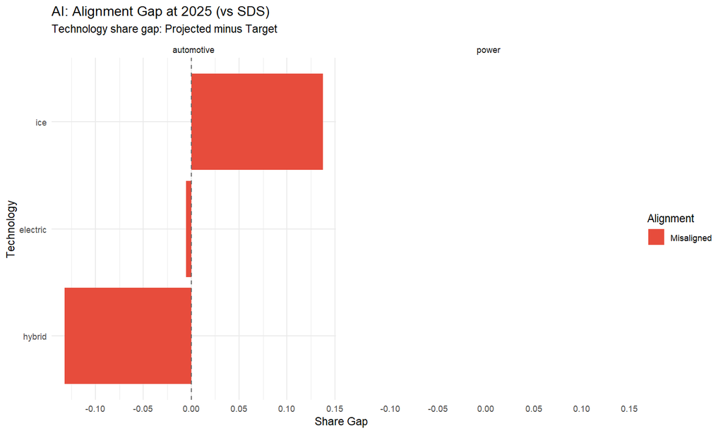

**Convergence:** Despite different matching strategies and visualization approaches, both implementations reach the same conclusions. The numerical differences in alignment gaps are minimal (within rounding tolerance), confirming both pipelines are correct.

## 9. Strengths & Weaknesses

### 9.1 AI Approach

Strengths

Weaknesses

- Comprehensive 10-section HTML report with KPI cards, callouts, and professional styling
- Company-level analysis (37K rows) for borrower-level engagement
- Explicit alignment gap calculations with direction-aware logic (low-carbon vs high-carbon)
- Multi-sector overview chart for quick visual summary
- Includes CPS scenario as additional benchmark line
- Detailed caveats and next steps sections
- No data labels on charts — exact values not readable
- Does not use the official `r2dii.plot` package (non-standard look)
- No sector mismatch validation step
- No PACTA methodology references or data dictionary
- No "Not in Scope" category in coverage analysis
- Missing ICE trajectory chart for automotive
- No Vietnam-specific context or guidance

## 10. Recommendations: Best of Both

For the production version targeting Vietnamese bank data, we recommend merging the best elements from both approaches:

### 10.1 Architecture

| Decision | Recommendation | Source |
| --- | --- | --- |
| Report format | Use **R Markdown** for the analytical notebook (literate programming), but also generate a **standalone HTML** for stakeholder distribution | Staff Rmd + AI HTML generator |
| Matching | Run fuzzy matching (`min_score = 0.9`) with **mandatory manual review** of matches scoring < 1.0. Export the match file, review, re-import | Hybrid: AI flexibility + Staff rigor |
| Sector classification | Pre-join sector classifications *before* matching (Staff pattern) to enable sector mismatch validation | Staff |
| Visualization | Use `r2dii.plot` for standardized charts + `ggrepel` labels. Keep custom ggplot2 for the alignment overview | Staff charts + AI overview |
| Coverage analysis | Include both the pie chart (portfolio-level) and bar chart (sector-level) with "Not in Scope" category | Staff |

### 10.2 Content

| Element | Recommendation | Source |
| --- | --- | --- |
| Methodology section | Adopt Staff's comprehensive methodology + data dictionary, add AI's metric explanation table | Both |
| Alignment calculation | Keep AI's explicit gap calculations + direction-aware alignment logic | AI |
| Company-level analysis | Keep AI's 37K-row company-level output for borrower engagement use | AI |
| Executive summary | Keep AI's KPI cards + callout summary format | AI |
| Caveats & next steps | Keep AI's detailed caveats section; merge with Staff's Vietnam context notes | Both |
| PACTA references | Adopt Staff's 5 official PACTA references | Staff |
| ICE trajectory | Add ICE trajectory chart (missing from AI) | Staff |
| Vietnam context | Expand Staff's notes on VSIC/NAICS mapping and ABCD challenges | Staff |

### 10.3 Immediate Next Steps

1. **Merge implementations:** Create a unified `scripts/pacta_production.R` that combines the best matching (fuzzy + manual review), analysis (portfolio + company level), and visualization (r2dii.plot + custom) approaches
2. **Build unified report template:** Create an `.Rmd` template with the AI's report structure and the Staff's r2dii.plot visualizations
3. **Prepare real data pipeline:** Adapt the loanbook input format for Vietnamese bank data, mapping VSIC codes to PACTA sector classifications
4. **Source ABCD data:** Investigate Asset Impact or alternative Vietnamese asset-level data sources (as Staff flagged, this is the "most challenging" input)
5. **Replace demo scenarios:** Source IEA WEO or NGFS scenarios appropriate for the Vietnam/ASEAN region
6. **Add quality controls:** Implement sector mismatch validation (Staff pattern) and match coverage thresholds before analysis

PACTA Comparison Report — AI vs Staff Implementation — Generated with `pacta.loanbook` (r2dii ecosystem) — February 2026  
This report is for internal review purposes.